# Experience vs. description based decision-making project: DDM parameter recovery with the `optim` function

# Setup

Set up environment and load in data

```r
source(paste0(helpers_path,'ddModels/fit_task.R'))
source(paste0(helpers_path,'ddModels/sim_task.R'))
test_trial_conditions = read.csv(paste0(helpers_path, 'ddModels/cluster_scripts/test_data/test_trial_conditions.csv'))
source(paste0(helpers_path, 'ddModels/ddm_par_recovery_report.R'))
```

Empty lists to store the trial simulators for the forthcoming models.

```r
sim_trial_list = list()
fit_trial_list = list()
```

```r
true_d = .06
true_sigma = .08
true_delta = 3
true_gamma = 3
```

# Prob distortion detection fails

## Model1b

With model1b, closest model to model2b without early integration

```r
source(paste0(helpers_path, 'ddModels/r_ddm_models/ddm_model1b.R'))

sim_trial_list[['model1b']] = sim_trial
fit_trial_list[['model1b']] = fit_trial
```

```r
trialsPerCondition=15

# Replicate same conditions n times
test_data = dplyr::bind_rows(replicate(trialsPerCondition, test_trial_conditions, simplify = FALSE))

# Simulate choice and RT for the replicated trial conditions
test_data = sim_task(test_data, model_name = "model1b", d = true_d, sigma = true_sigma, delta = true_delta, gamma = true_gamma) %>%drop_na()
```

Example 1: c(.01, .01, 1, 1)

```r
optim_out = optim_save(c(.01, .01, 1, 1), get_task_nll, data=test_data, par_names = c("d", "sigma", "delta", "gamma"), model_name="model1b", control = list(maxit=75))
```

```r
optim_out$par
```

```
## [1] 0.05655680 0.08468402 0.90702687 1.07993870
```

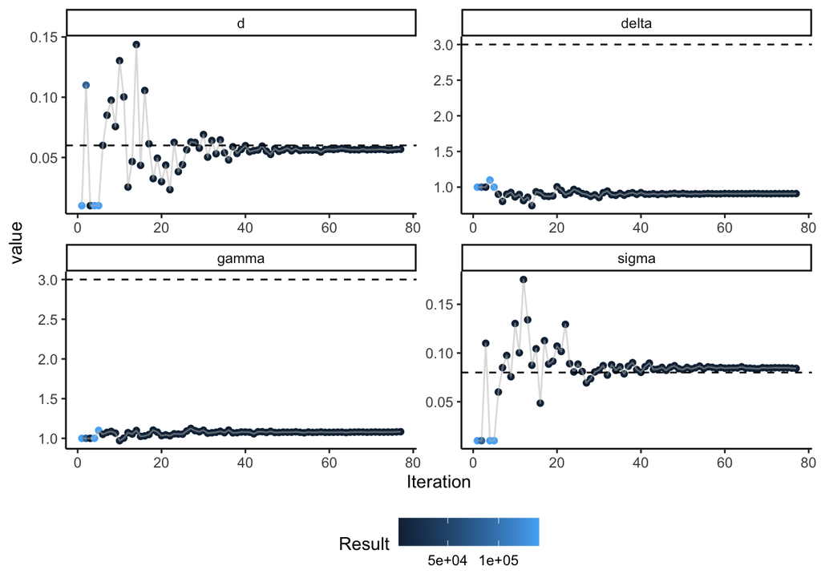

```r
tmp = data.frame(key = c("d", "sigma", "delta", "gamma"), true_val = c(true_d, true_sigma, true_delta, true_gamma))

optim_out$iterations_df %>%
  gather(key, value, -Result, -Iteration) %>%
  mutate(key =ifelse(key == "Param1", "d", ifelse(key == "Param2", "sigma", ifelse(key == "Param3", "delta", "gamma")))) %>%
  ggplot(aes(Iteration, value))+
  geom_point(aes(color=Result))+
  geom_line(alpha=.5, color="gray")+
  facet_wrap(~key, scales="free")+
  geom_hline(data=tmp, aes(yintercept = true_val), linetype="dashed")+
  theme(legend.position="bottom")
```

### Path plots

Path plots to see how to think through the perturbations

How is a particle supposed to move with the Nelder-Mead algorithm? [Here’s a quick tutorial](http://www.brnt.eu/phd/node10.html#SECTION00622200000000000000) on how it works [Here’s some R code that walks through the moves of the simplex](https://m-clark.github.io/models-by-example/nelder-mead.html)

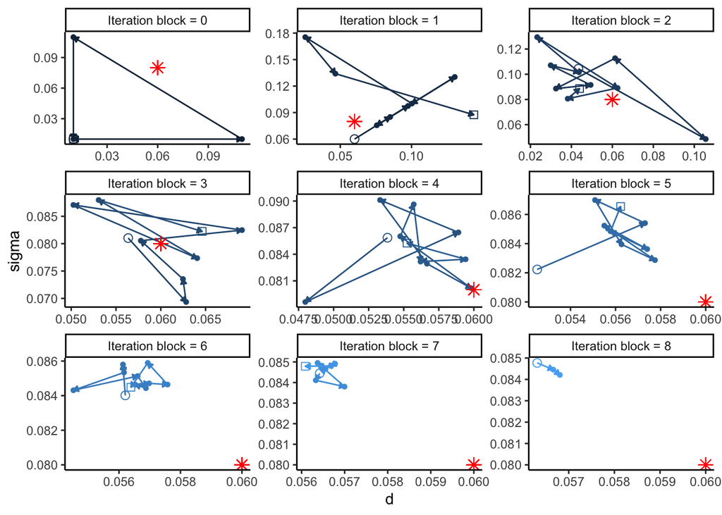

```r
optim_out$iterations_df %>%
  mutate(iter_block = round(Iteration/10),
         start_point = c(1,diff(iter_block)),
         end_point = -1*lead(c(0, diff(iter_block))),
         end_point = ifelse(is.na(end_point), 0, end_point),
         point_shape = as.factor(start_point+end_point),
         iter_block = paste0("Iteration block = ", iter_block)) %>%
  rename(d= Param1, sigma = Param2)%>%
  ggplot(aes(d, sigma, color=Iteration))+
  geom_point(aes(shape=point_shape, size=point_shape))+
  geom_path(arrow = arrow(type = "closed", length = unit(0.05, "npc")))+
  geom_point(aes(x = true_d, y = true_sigma), size=3, color="red", pch=8)+
  facet_wrap(~iter_block, scales="free")+
  theme(legend.position = "none")+
  scale_shape_manual(values = c(22,20,21))+
  scale_size_manual(values=c(2.5,2,2.5))
```

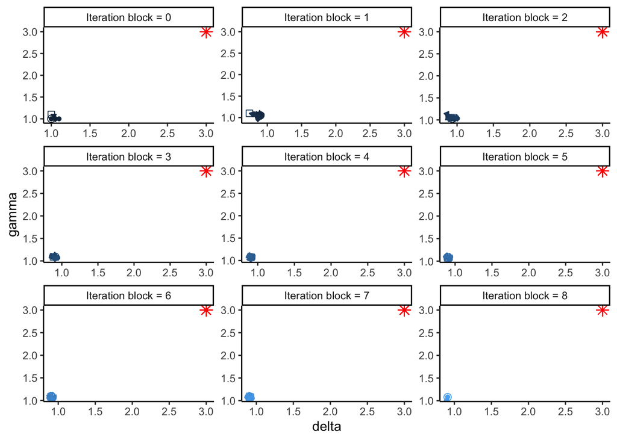

```r
optim_out$iterations_df %>%
  mutate(iter_block = round(Iteration/10),
         start_point = c(1,diff(iter_block)),
         end_point = -1*lead(c(0, diff(iter_block))),
         end_point = ifelse(is.na(end_point), 0, end_point),
         point_shape = as.factor(start_point+end_point),
         iter_block = paste0("Iteration block = ", iter_block)) %>%
  rename(delta= Param3, gamma = Param4)%>%
  ggplot(aes(delta, gamma, color=Iteration))+
  geom_point(aes(shape=point_shape, size=point_shape))+
  geom_path(arrow = arrow(type = "closed", length = unit(0.05, "npc")))+
  geom_point(aes(x = true_delta, y = true_gamma), size=3, color="red", pch=8)+
  facet_wrap(~iter_block, scales="free")+
  theme(legend.position = "none")+
  scale_shape_manual(values = c(22,20,21))+
  scale_size_manual(values=c(2.5,2,2.5))
```

## Model1a

Alternative parameterization of probability distortion

How do things look like with a differently parameterized prob distortion function? How does the prob distortion and the ranges of the parameters change?

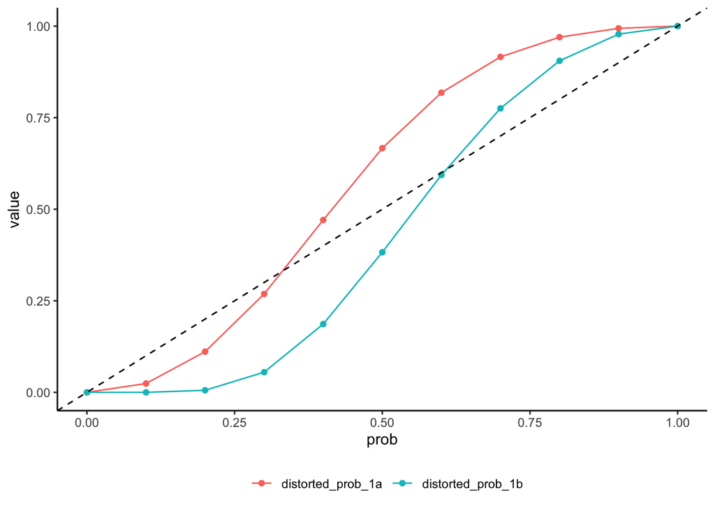

```r
delt = 2
gamm = 2

data.frame(prob = seq(0,1,.1)) %>%
  mutate(distorted_prob_1a = (delt * (prob)^gamm) / ( (delt * (prob)^gamm) + (1-prob)^gamm ),
         distorted_prob_1b = exp(-delt*(-log(prob))^gamm)  ) %>%
  gather(key, value, -prob) %>%
  ggplot(aes(prob, value, color=key))+
  geom_point()+
  geom_line()+
  geom_abline(aes(intercept=0, slope = 1), linetype="dashed")+
  theme(legend.position = "bottom")+
  labs(color="")
```

```r
source(paste0(helpers_path, 'ddModels/r_ddm_models/ddm_model1a.R'))

sim_trial_list[['model1a']] = sim_trial
fit_trial_list[['model1a']] = fit_trial
```

Is recovery any better for these prob distortion parameters? No.

```r
trialsPerCondition=15

# Replicate same conditions n times
test_data = dplyr::bind_rows(replicate(trialsPerCondition, test_trial_conditions, simplify = FALSE))

# Simulate choice and RT for the replicated trial conditions
test_data = sim_task(test_data, model_name = "model1a", d = true_d, sigma = true_sigma, delta = true_delta, gamma = true_gamma) %>%drop_na()
```

```r
optim_out = optim_save(c(.01, .01, 1, 1), get_task_nll, data=test_data, par_names = c("d", "sigma", "delta", "gamma"), model_name="model1a", control = list(maxit=75))
```

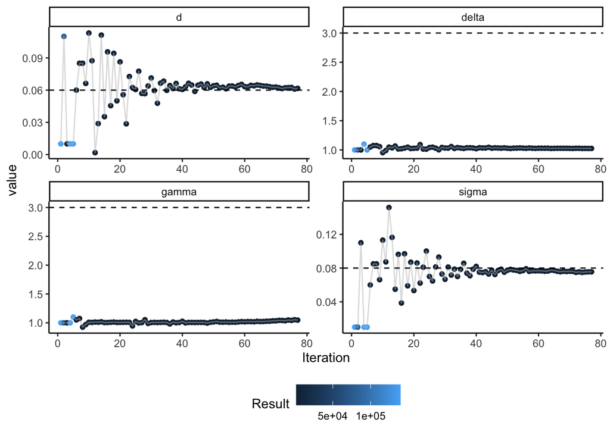

```r
tmp = data.frame(key = c("d", "sigma", "delta", "gamma"), true_val = c(true_d, true_sigma, true_delta, true_gamma))

optim_out$iterations_df %>%
  gather(key, value, -Result, -Iteration) %>%
  mutate(key =ifelse(key == "Param1", "d", ifelse(key == "Param2", "sigma", ifelse(key == "Param3", "delta", "gamma")))) %>%
  ggplot(aes(Iteration, value))+
  geom_point(aes(color=Result))+
  geom_line(alpha=.5, color="gray")+
  facet_wrap(~key, scales="free")+
  geom_hline(data=tmp, aes(yintercept = true_val), linetype="dashed")+
  theme(legend.position="bottom")
```

### Path plots

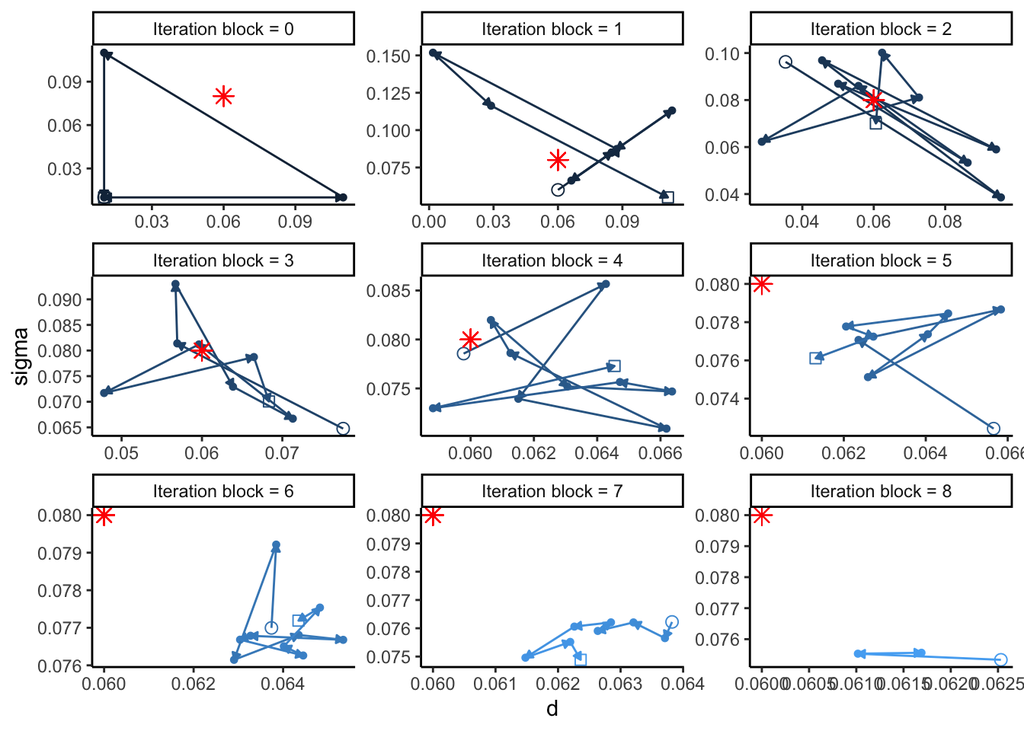

```r
optim_out$iterations_df %>%
  mutate(iter_block = round(Iteration/10),
         start_point = c(1,diff(iter_block)),
         end_point = -1*lead(c(0, diff(iter_block))),
         end_point = ifelse(is.na(end_point), 0, end_point),
         point_shape = as.factor(start_point+end_point),
         iter_block = paste0("Iteration block = ", iter_block)) %>%
  rename(d= Param1, sigma = Param2)%>%
  ggplot(aes(d, sigma, color=Iteration))+
  geom_point(aes(shape=point_shape, size=point_shape))+
  geom_path(arrow = arrow(type = "closed", length = unit(0.05, "npc")))+
  geom_point(aes(x = true_d, y = true_sigma), size=3, color="red", pch=8)+
  facet_wrap(~iter_block, scales="free")+
  theme(legend.position = "none")+
  scale_shape_manual(values = c(22,20,21))+
  scale_size_manual(values=c(2.5,2,2.5))
```

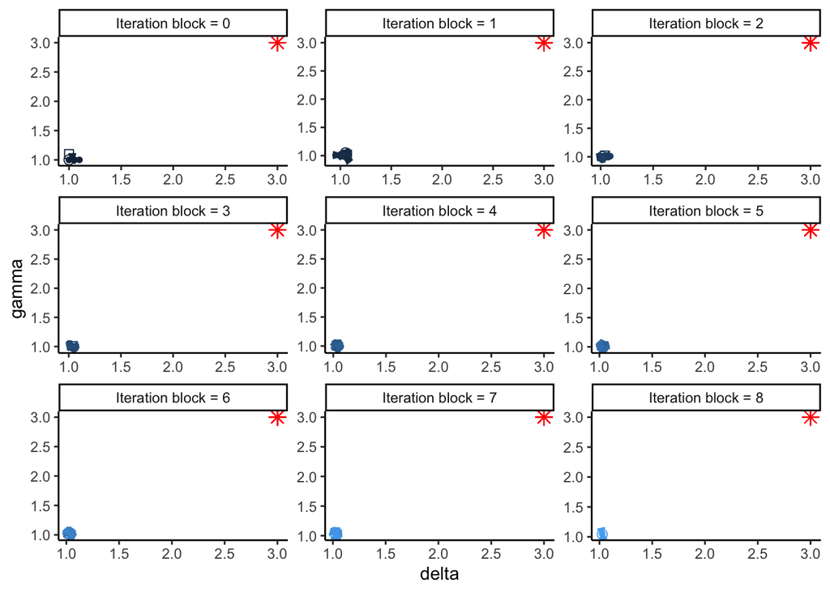

```r
optim_out$iterations_df %>%
  mutate(iter_block = round(Iteration/10),
         start_point = c(1,diff(iter_block)),
         end_point = -1*lead(c(0, diff(iter_block))),
         end_point = ifelse(is.na(end_point), 0, end_point),
         point_shape = as.factor(start_point+end_point),
         iter_block = paste0("Iteration block = ", iter_block)) %>%
  rename(delta= Param3, gamma = Param4)%>%
  ggplot(aes(delta, gamma, color=Iteration))+
  geom_point(aes(shape=point_shape, size=point_shape))+
  geom_path(arrow = arrow(type = "closed", length = unit(0.05, "npc")))+
  geom_point(aes(x = true_delta, y = true_gamma), size=3, color="red", pch=8)+
  facet_wrap(~iter_block, scales="free")+
  theme(legend.position = "none")+
  scale_shape_manual(values = c(22,20,21))+
  scale_size_manual(values=c(2.5,2,2.5))
```

# Change in NLL as a function of change in parameters

Why don’t delta and gamma move? Why were we able to estimate the correct d and sigma even when delta and gamma were incorrectly fixed at 1? Because changing them even drastically leads to very small improvement in the objective function (nll).

```r
true_nll = get_task_nll(test_data, par_ = c(true_d, true_sigma, true_delta, true_gamma), par_names_ = c("d", "sigma", "delta", "gamma"), model_name_ = "model1a")
true_nll
```

```
## [1] 1716.633
```

Proportional difference in NLL when using different delta and gamma values compared to the true NLL.

In this specific example, the absence of a big difference between setting delta and gamma to 1 (compared to the true value of 3 which leads to distortion) means that the recovery can’t tell if there is prob distortion or not.

```r
(get_task_nll(test_data, par_ = c(true_d, true_sigma, 1, 1), par_names_ = c("d", "sigma", "delta", "gamma"), model_name_ = "model1a")-true_nll)/true_nll
```

```
## [1] 0.01370021
```

```r
(get_task_nll(test_data, par_ = c(true_d, true_sigma, 2, 2), par_names_ = c("d", "sigma", "delta", "gamma"), model_name_ = "model1a")-true_nll)/true_nll
```

```
## [1] 0.0008814106
```

On the other hand, a similar change in d and sigma leads to a massive difference

```r
(get_task_nll(test_data, par_ = c(true_d/3, true_sigma/3, 1, 1), par_names_ = c("d", "sigma", "delta", "gamma"), model_name_ = "model1a")-true_nll)/true_nll
```

```
## [1] 5.960276
```

What is the effect of changing the distortion parameters (delta and gamma) on the likelihood computation compared to the change in the other parameters?

The likelihood computation depends on the distribution `N(mu, sigma)` where mu is determined by the option values and the distorted probability of attribute relevance. Sigma has a direct effect on this distribution. The effect of the drift rate, delta and gamma are indirect through the following equations:

```
distortedProbFractalDraw = (delta * (probFractalDraw)^gamma) / ( (delta * (probFractalDraw)^gamma) + (1-probFractalDraw)^gamma )
leftFractalAdv =  distortedProbFractalDraw * (QVLeft - QVRight)
leftLotteryAdv = (1-probFractalDraw) * (EVLeft - EVRight)
mu = d * (leftFractalAdv + leftLotteryAdv)
```

- Increasing the drift rate has a consistent effect for all trial conditions that scales with the size of the change.
- Increasing delta has a small and somewhat variable effect.
- Increasing gamma has an effect larger than changing delta but smaller than changing the drift rate and it is most variable.

```r
delt = 2
gamm = 2
dR = .03
changeFactor = seq(1.1, 2, .1)

tmp = bind_rows(replicate(length(changeFactor), test_trial_conditions, simplify = FALSE)) %>%
  cbind(bind_rows(replicate(nrow(test_trial_conditions), data.frame(changeFactor), simplify = FALSE)) %>%
          arrange(changeFactor))  %>%
  mutate(QVDiff = QVLeft-QVRight,
         EVDiff = EVLeft-EVRight,
         distortedProb = (delt * (probFractalDraw)^gamm) / ( (delt * (probFractalDraw)^gamm) + (1-probFractalDraw)^gamm ),
         distortedProbDelt = (delt * changeFactor * (probFractalDraw)^gamm) / ( (delt* changeFactor * (probFractalDraw)^gamm) + (1-probFractalDraw)^gamm ),
         distortedProbGamm = (delt * (probFractalDraw)^(gamm* changeFactor)) / ( (delt* changeFactor * (probFractalDraw)^(gamm* changeFactor)) + (1-probFractalDraw)^(gamm* changeFactor) ),
         mu = dR * ( (distortedProb*QVDiff) + ((1-probFractalDraw)*EVDiff) ),
         mu_driftRateChange =  dR *changeFactor* ( (distortedProb*QVDiff) + ((1-probFractalDraw)*EVDiff) ),
         mu_deltaChange = dR * ( (distortedProbDelt*QVDiff) + ((1-probFractalDraw)*EVDiff) ),
         mu_gammaChange = dR * ( (distortedProbGamm*QVDiff) + ((1-probFractalDraw)*EVDiff) ) ) %>%
  select(mu, mu_driftRateChange, mu_deltaChange, mu_gammaChange, changeFactor) %>%
  gather(key, value, -mu, -changeFactor) %>%
  mutate(muAbsDiff = abs(abs(value) - abs(mu)),
         muPropDiff = muAbsDiff / abs(mu))

tmp %>%
  group_by(key, changeFactor) %>%
  summarise(meanPropDiff = mean(muPropDiff),
            semPropDiff = sem(muPropDiff), .groups="keep")
```

```
## # A tibble: 30 x 4
## # Groups:   key, changeFactor [30]
##    key            changeFactor meanPropDiff semPropDiff
##    <chr>                 <dbl>        <dbl>       <dbl>
##  1 mu_deltaChange          1.1       0.0203     0.00609
##  2 mu_deltaChange          1.2       0.0390     0.0118
##  3 mu_deltaChange          1.3       0.0563     0.0173
##  4 mu_deltaChange          1.4       0.0725     0.0225
##  5 mu_deltaChange          1.5       0.0877     0.0276
##  6 mu_deltaChange          1.6       0.102      0.0325
##  7 mu_deltaChange          1.7       0.116      0.0372
##  8 mu_deltaChange          1.8       0.128      0.0419
##  9 mu_deltaChange          1.9       0.141      0.0464
## 10 mu_deltaChange          2         0.152      0.0508
## # … with 20 more rows
```

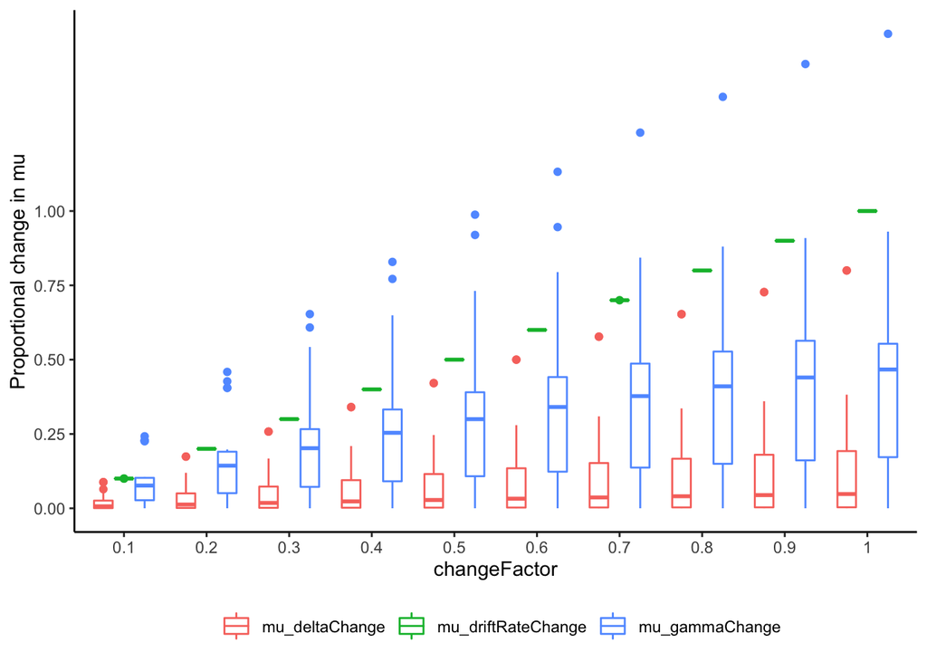

```r
tmp %>%
  mutate(changeFactor = as.factor(changeFactor-1)) %>%
  ggplot(aes(changeFactor, muPropDiff, color=key))+
  geom_boxplot()+
  theme(legend.position = "bottom")+
  scale_y_continuous(breaks=c(0, .25, .5, .75, 1, 2, 3))+
  labs(color="", y="Proportional change in mu")
```

I think this suggests that the objective function (the likelihood computation) is not sensitive to pick up changes in delta and gamma. Possible next steps:

- Changing the objective function might help, but what to change it to?
  - Read a recent paper on probability distortion functions ([Zhang, Ren, Maloney, 2020, PNAS](https://www.pnas.org/content/117/36/22024#sec-23)) but wasn’t sure how to make use of it for a different likelihood function
- Likelihood surface depending on the delta and gamma - would a (big) grid search be the answer? See previous notebook.
  - Change is larger for change in levels of gamma versus delta
- Changing the perspective: instead of trying to recover exact model parameters, distinguish between a model with distortion versus no distortion?
- Moving to joint modeling of choice and RT with Stan by expanding the previous RL models? How well did these RL only do in parameter recovery?
  - How do [Shahar et al., 2019](https://journals.plos.org/ploscompbiol/article?id=10.1371/journal.pcbi.1006803#sec008) do it? They model a two two-step task with a combined DDM-RL model. The addition of DDM helps recovering learning rate and model-based vs model-free allocation weight parameter to be recovered in much fewer trials.

# Perturbing the kernel **[paused]**

How much to perturb in what dimension? Stopping criteria for perturbations? Two potentially relevant papers:

- [The Nelder–Mead simplex algorithm with perturbed centroid for high-dimensional function optimization](https://link.springer.com/article/10.1007/s11590-018-1306-2)
- [Stochastic Nelder–Mead simplex method – A new globally convergent direct search method for simulation optimization](https://www.sciencedirect.com/science/article/pii/S0377221712001609#b0175)

They are theoretically interesting but unfortunately neither includes code and I’m reluctant to implement the described algorithms myself.

# Stop clusters

```r
parallel::stopCluster(cl = my.fit.cluster)
parallel::stopCluster(cl = my.sim.cluster)
```

What do we know so far?  
Slight lottery bias in pooled data  
Categorically faster RTs when probFractalDraw == 1 in pooled data  
Slower decisions the more both attributes need to be considered in pooled data  
Individual differences both in all of the above stylized facts and in the best fitting RL model  
What will we do with these parameters?  
Individual difference analyses?  
Trial level covariate for imaging?  
Move things over to remote cluster for subject estimation?  
Combined DDM + RL modeling:  
Would you be able to take advantage of `foreach` package in `sim_task` and `fit_task` while also serially updating QValues?  
Without paralellization how would you implement it in `sim_task` and `fit_task` with serial updating of QValues?  
Would it be possible to implement in Stan?